# Zadania_3

Daria Bozhkova

2026-04-03

## 3.1. Jednoduchá logistická regresia

*Vytvorme logisticky regresny model modelujúci prejdenie skúškou a spocitame korelaciu.*

```r
data31 <- data.frame(
study_hours = c(2, 3, 5, 7, 8, 10, 11, 13, 15, 16),
pass = c(0, 0, 0, 1, 1, 1, 1, 1, 1, 1)
) # 0: fail, 1: pass

korelacia <- cor(data31$study_hours, data31$pass, method = "spearman") #lebo jedna premenna binarna
print(paste("Korelacia Spearmena:", round(korelacia, 4)))
```

```
## [1] "Korelacia Spearmena: 0.7977"
```

*Zostrojme GLM (Generalized Linear Model):*

```r
model31 <- glm(pass ~ study_hours, data = data31, family = binomial) #binomial for logit
summary(model31)
```

```
##
## Call:
## glm(formula = pass ~ study_hours, family = binomial, data = data31)
##
## Coefficients:
##              Estimate Std. Error z value Pr(>|z|)
## (Intercept)   -134.44  193058.17  -0.001    0.999
## study_hours     22.39   31296.13   0.001    0.999
##
## (Dispersion parameter for binomial family taken to be 1)
##
##     Null deviance: 1.2217e+01  on 9  degrees of freedom
## Residual deviance: 7.5703e-10  on 8  degrees of freedom
## AIC: 4
##
## Number of Fisher Scoring iterations: 25
```

Estimate (vyjadruju vplyv na logit): V pripade, ze student vobec nestudoval, p-t uspechu ide k nule (Intercept hodnota je zaporna); study_hours ukazuje, ze kazda hodina studia zvacsuje sancu na uspech (logaritmus).

Problem tu je v tom, ze nam ukazuje velmi velki Std.Error a p-value este aj hovori, ze faktor nie je vyznamny. Ale vykaslame na to, residual deviance blizko nuly - to je podstatne.

*Vyratame confusion maticu a metriky modelu*: (Aby pochopit akost modelu porovnavame predpoklady a slutocne hodnoty)

```r
prob <- predict(model31, type="response") #response - S function results (0-1)
pred_class <- ifelse(prob >= 0.5, 1, 0)

conf_matrix <- table(Actual = data31$pass, Predocted = pred_class)
print(conf_matrix)
```

```
##       Predocted
## Actual 0 1
##      0 3 0
##      1 0 7
```

```r
accuracy <- sum(diag(conf_matrix)) / sum(conf_matrix)
precision <- conf_matrix[2,2] / sum(conf_matrix[,2])
recall <- conf_matrix[2,2] / sum(conf_matrix[2,])

print(paste("Accuracy:", accuracy))
```

```
## [1] "Accuracy: 1"
```

```r
print(paste("Precision:", round(precision, 4)))
```

```
## [1] "Precision: 1"
```

```r
print(paste("Recall:", round(recall, 4)))
```

```
## [1] "Recall: 1"
```

*Nakoniec ziskame odpoved na otazku “Prešiel by, na základe modelu, student, ktorý venoval príprave 6 hodín?”:*

```r
new_student <- data.frame(study_hours = 6)
prob_6h <- predict(model31, new_student, type = "response")

print(paste("Pravdepodobnost uspesneho absolvovania pri 6 hod. :", round(prob_6h, 4)))
```

```
## [1] "Pravdepodobnost uspesneho absolvovania pri 6 hod. : 0.478"
```

```r
result <- ifelse(prob_6h >= 0.5, "Prejde (1)", "Nie prejde (0)")
print(result)
```

```
##                1
## "Nie prejde (0)"
```

6 hodin nachadza presne uprostred medzi bodom zaruceneho neuspehu (5) a uspechu (7), model vykazuje p-t blizku 0.5. Sice hovorme, ze student skusku nezlozi, jeho vysledok je hranicny.

## 3.2. Násobná logistická regresia – generované dáta

*Vytvorme logistický regresný model modelujúci pravdepodobnosť kúpenia produktu (premenná purchase):*

```r
data32 <- data.frame(
  age = c(25, 30, 35, 40, 45, 50, 55, 60, 65, 70),
  gender = factor(c("male", "female", "female", "male", "male", "female", "female", "male", "male", "female")),
  income = c(50, 55, 60, 65, 70, 75, 80, 85, 90, 95),
  ad_click = c(1, 1, 0, 0, 1, 0, 1, 1, 0, 1),
  purchase = c(0, 0, 1, 1, 0, 1, 0, 1, 1, 0)
) # 0: no, 1: yes
```

Vizualne je vidno, ze vek koreluje s prijmom, ale vypocitame pre prehliadnost:

```r
cor_age_income <- cor(data32$age, data32$income)
print(paste("Korelacia veku a prijmu:", round(cor_age_income, 4)))
```

```
## [1] "Korelacia veku a prijmu: 1"
```

Ano, je to tak, income = age + 25.

*Dalej zostrojme model:*

```r
model32 <- glm(purchase ~ age + gender + income + ad_click, data = data32, family = binomial)
summary(model32)
```

```
##
## Call:
## glm(formula = purchase ~ age + gender + income + ad_click, family = binomial,
##     data = data32)
##
## Coefficients: (1 not defined because of singularities)
##               Estimate Std. Error z value Pr(>|z|)
## (Intercept)    -83.480 244529.833   0.000        1
## age              3.084   6025.081   0.001        1
## gendermale      78.168 157973.344   0.000        1
## income              NA         NA      NA       NA
## ad_click      -156.524 266443.732  -0.001        1
##
## (Dispersion parameter for binomial family taken to be 1)
##
##     Null deviance: 1.3863e+01  on 9  degrees of freedom
## Residual deviance: 4.7545e-10  on 6  degrees of freedom
## AIC: 8
##
## Number of Fisher Scoring iterations: 25
```

Vzhladom na to, ze premenne age a income su v idealnej korelacii, doslo k uplnej multikolinearite. Model automaticky vylucil premennú income (NA), pretoze duplikuje informacie z premennej age.

age - z vekom p-t nakupu sa zvysuje; gendermale (kladny koef.) - muzi nakupuju castejsie ako zeny; ad_click (zaporny) - kliknutie na reklamu nezvysuje (resp. zmensuje) p-t nakupu.

*Teraz matica a metriky:*

```r
prob32 <- predict(model32, type = "response")
pred_class32 <- ifelse(prob32 >= 0.5, 1, 0)

conf_matrix32 <- table(Actual = data32$purchase, Predicted = pred_class32)
print("Confusion Matrix:")
```

```
## [1] "Confusion Matrix:"
```

```r
print(conf_matrix32)
```

```
##       Predicted
## Actual 0 1
##      0 5 0
##      1 0 5
```

```r
accuracy32 <- sum(diag(conf_matrix32)) / sum(conf_matrix32)
precision32 <- conf_matrix32[2,2] / sum(conf_matrix32[,2])
recall32 <- conf_matrix32[2,2] / sum(conf_matrix32[2,])

cat(" Accuracy:", accuracy32, "\n",
    "Precision:", round(precision32, 4), "\n",
    "Recall:", round(recall32, 4))
```

```
##  Accuracy: 1
##  Precision: 1
##  Recall: 1
```

Kedze presnost, preciznost a recall dosahuju hodnotu 1, model je pre tento trenovací subor udajov idealny (opat vdaka efektu dokonaleho oddelenia).

## 3.3. Násobná logistická regresia - dataset

Cielom je predpovedat typ prevodovky (am) na zaklade vykonu (hp) a hmotnosti (wt). *Zostrojme model*

```r
model_mtcars <- glm(am ~ hp + wt, data = mtcars, family = binomial)
summary(model_mtcars)
```

```
##
## Call:
## glm(formula = am ~ hp + wt, family = binomial, data = mtcars)
##
## Coefficients:
##             Estimate Std. Error z value Pr(>|z|)
## (Intercept) 18.86630    7.44356   2.535  0.01126 *
## hp           0.03626    0.01773   2.044  0.04091 *
## wt          -8.08348    3.06868  -2.634  0.00843 **
## ---
## Signif. codes:  0 '***' 0.001 '**' 0.01 '*' 0.05 '.' 0.1 ' ' 1
##
## (Dispersion parameter for binomial family taken to be 1)
##
##     Null deviance: 43.230  on 31  degrees of freedom
## Residual deviance: 10.059  on 29  degrees of freedom
## AIC: 16.059
##
## Number of Fisher Scoring iterations: 8
```

Koeficienty: wt(hmotnost) - zaporny, tazke vozidla maju castejsie automaticku prevodovku (0). Narast hmotnosty znizuje p-t manualnej prevodovky (1); hp(vykon) - kladny, sportove auta s velkym vykonom maju casto manualnu prevodovku pre lepsiu kontrolu.

*Zostojme maticu:*

```r
prob_mtcars <- predict(model_mtcars, type = "response")
pred_mtcars <- ifelse(prob_mtcars >= 0.5, 1, 0)

conf_matrix33 <- table(Actual = mtcars$am, Predicted = pred_mtcars)
print("Confusion Matrix:")
```

```
## [1] "Confusion Matrix:"
```

```r
print(conf_matrix32)
```

[output not shown]

```r
accuracy33 <- sum(diag(conf_matrix33)) / sum(conf_matrix33)
precision33 <- conf_matrix33[2,2] / sum(conf_matrix33[,2])
recall33 <- conf_matrix33[2,2] / sum(conf_matrix33[2,])

cat(" Accuracy:", accuracy33, "\n",
    "Precision:", round(precision33, 4), "\n",
    "Recall:", round(recall33, 4))
```

```
##  Accuracy: 0.9375
##  Precision: 0.9231
##  Recall: 0.9231
```

```r
library(pROC)
roc_obj <- roc(mtcars$am, prob_mtcars)
```

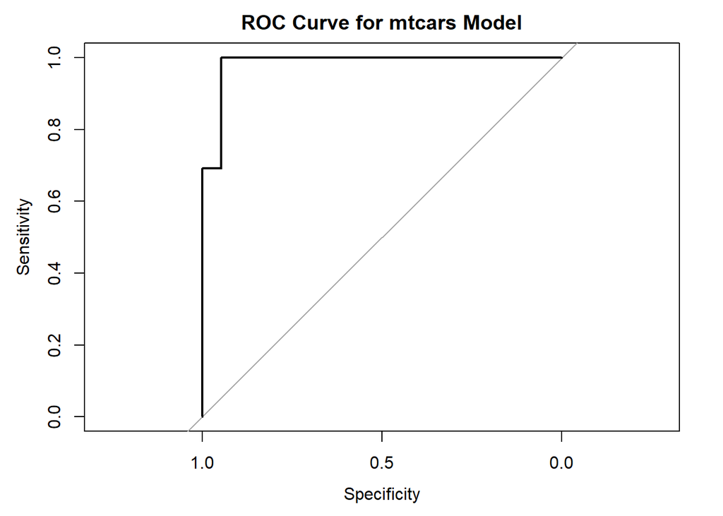

```r
plot(roc_obj, main ="ROC Curve for mtcars Model")
```

```r
print(paste("AUC:", auc(roc_obj)))
```

```
## [1] "AUC: 0.983805668016194"
```

**- Sú v danom datasete premenné, ktoré dávajú lepší model a ak áno, ktoré to sú?** Je to tricky question, lebo model uz je sikovny (AUC > 0.98).

```r
full_model <- glm(am ~ ., data = mtcars, family = binomial)
best_model <- suppressWarnings(step(full_model, direction = "both", trace = FALSE))
summary(best_model)
```

```
##
## Call:
## glm(formula = am ~ qsec + gear + carb, family = binomial, data = mtcars)
##
## Coefficients:
##              Estimate Std. Error z value Pr(>|z|)
## (Intercept)    360.96  484751.44   0.001    0.999
## qsec           -41.21   38378.81  -0.001    0.999
## gear           130.03  111642.78   0.001    0.999
## carb           -39.31   41152.05  -0.001    0.999
##
## (Dispersion parameter for binomial family taken to be 1)
##
##     Null deviance: 4.3230e+01  on 31  degrees of freedom
## Residual deviance: 2.0927e-09  on 28  degrees of freedom
## AIC: 8
##
## Number of Fisher Scoring iterations: 25
```

Residual deviance blizko nuly a AIC teraz 8 (ale nie 16 ako bolo v predoslom), super.

```r
library(pROC)
prob_old <- predict(model_mtcars, type = "response")
auc_old <- auc(roc(mtcars$am, prob_old))
prob_new <- predict(best_model, type = "response")
auc_new <- auc(roc(mtcars$am, prob_new))
print(paste("AUC mojho modelu:", round(auc_old, 4)))
```

```
## [1] "AUC mojho modelu: 0.9838"
```

```r
print(paste("AUC modelu po step():", round(auc_new, 4)))
```

```
## [1] "AUC modelu po step(): 1"
```

Ano, je mozne najst lepsi model, a to je model s pouzitim qsec + gear + carb.